# Machine Learning Project

# Question 4

**Question**: The effect of the education on the account status of the customers.

**Answer**:

## Summary Table

```r
credit_card_df %>% count(customer_status, education) %>%
    group_by(customer_status) %>%
    mutate(pct=n/sum(n))
```

| customer_status | education | n | pct |
| --- | --- | --- | --- |
| closed_account | associates | 874 | 0.41778203 |
| closed_account | bachelors | 201 | 0.09608031 |
| closed_account | masters | 891 | 0.42590822 |
| closed_account | doctorate | 126 | 0.06022945 |
| active | associates | 1053 | 0.41538462 |
| active | bachelors | 268 | 0.10571992 |
| active | masters | 1104 | 0.43550296 |
| active | doctorate | 110 | 0.04339250 |

## Data Visualization

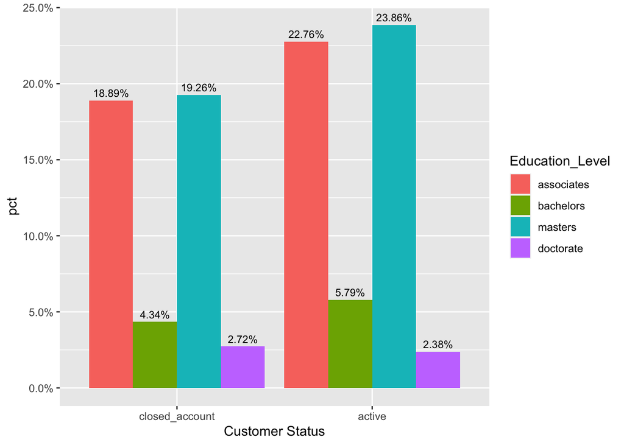

```r
credit_card_df %>%
  ggplot(aes(x=factor(customer_status),
             y=prop.table(stat(count)),
             fill = factor(education),
             label = scales::percent(prop.table(stat(count))))) +
  geom_bar(position = 'dodge') +
  geom_text(stat = 'count',
            position = position_dodge(.9),
            vjust = -0.5,
            size = 3) +
  scale_y_continuous(labels = scales::percent) +
  labs(x= 'Customer Status', y='pct', fill = 'Education_Level')
```

# Question 5

**Question**: Is there any relationship between the expenditure performed by the clients with their account status?

**Answer**:

## Summary Table

```r
credit_card_df %>% group_by(customer_status) %>%
  summarise(avg_trans=mean(total_spend_last_year),
            max_trans= max(total_spend_last_year),
            min_trans= min(total_spend_last_year))
```

| customer_status | avg_trans | max_trans | min_trans |
| --- | --- | --- | --- |
| closed_account | 3120.827 | 10583 | 510 |
| active | 4596.663 | 17498 | 893 |

## Data Visualization

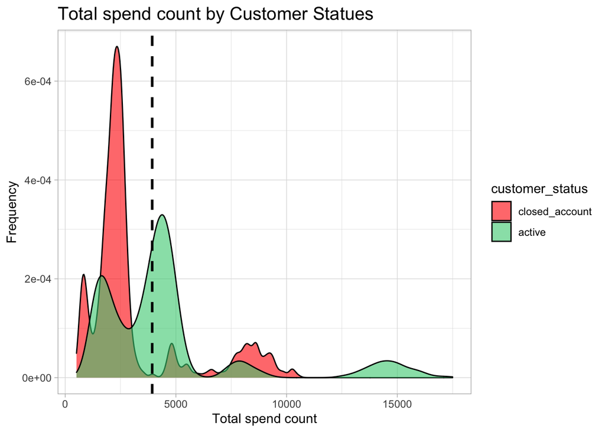

```r
credit_card_df %>%ggplot( aes(x=total_spend_last_year, fill=customer_status)) +geom_density(alpha=0.6) +geom_vline(aes(xintercept=mean(total_spend_last_year)),color="black", linetype="dashed", size=1)+theme_light() + scale_fill_manual(values = c("red", "seagreen3"))+ggtitle("Total spend count by Customer Statues") +xlab("Total spend count")+ylab("Frequency")+ theme(plot.title = element_text(size=15))
```

# Machine Learning

In this section of the project, you will fit **three classification algorithms** to predict the outcome variable,`customer_status`.

You must follow the machine learning steps below.

The data splitting and feature engineering steps should only be done once so that your models are using the same data and feature engineering steps for training.

- Split the `credit_card_df` data into a training and test set (remember to set your seed)
- Specify a feature engineering pipeline with the `recipes` package
  - You can include steps such as skewness transformation, correlation filters, dummy variable encoding or any other steps you find appropriate
- Specify a `parsnip` model object
  - You may choose from the following classification algorithms:
    - Logistic Regression
    - LDA
    - QDA
    - KNN
    - Decision Tree
    - Random Forest
- Package your recipe and model into a workflow
- Fit your workflow to the training data
  - If your model has hyperparameters:
    - Split the training data into 5 folds for 5-fold cross validation using `vfold_cv` (remember to set your seed)
    - Perform hyperparamter tuning with a random grid search using the `grid_random()` function
    - Refer to the following tutorial for an example - [Random Grid Search](https://gmubusinessanalytics.netlify.app/lesson-08-r-tutorial.html#Hyperparameter_Tuning14)
    - Hyperparameter tuning can take a significant amount of computing time. Be careful not to set the `size` argument of `grid_random()` too large. I recommend `size` = 10 or smaller.
    - Select the best model with `select_best()` and finalize your workflow
- Evaluate model performance on the test set by plotting an ROC curve using `autoplot()` and calculating the area under the ROC curve on your test data

# Dividing data into train and test split

```r
set.seed(123)
customer_split <- initial_split(credit_card_df, prop = 0.80,
                                strata = customer_status)
customer_training <- customer_split %>% training()
customer_test <- customer_split %>% testing()
```

# Feature Engineering

```r
customer_recipe <- recipe(customer_status ~ ., data = customer_training) %>%
                step_YeoJohnson(all_numeric(), -all_outcomes()) %>%
                step_normalize(all_numeric(), -all_outcomes()) %>%
                step_dummy(all_nominal(), -all_outcomes()) %>% prep()
```

# Model 1 (Logistic Regression)

```r
logistic_model <- logistic_reg() %>%
                  set_engine('glm') %>%
                  set_mode('classification')
customer_wf <- workflow() %>%
            add_model(logistic_model) %>%
            add_recipe(customer_recipe)
customer_logistic_fit <- customer_wf %>%
                      fit(data = customer_training)

predictions_categories <- predict(customer_logistic_fit,
                                  new_data = customer_test)

predictions_probabilities <- predict(customer_logistic_fit,
                                     new_data = customer_test,
                                     type = 'prob')


test_results <- customer_test %>% select(customer_status) %>%
                bind_cols(predictions_categories) %>%
                bind_cols(predictions_probabilities)
my_metrics <- metric_set(accuracy, sens, spec, f_meas, roc_auc)

last_fit_model <- customer_wf %>%
                  last_fit(split = customer_split,
                           metrics = my_metrics)
last_fit_results <- last_fit_model %>%
                     collect_predictions()
last_fit_model %>% collect_metrics()
```

| .metric | .estimator | .estimate | .config |
| --- | --- | --- | --- |
| accuracy | binary | 0.8585313 | Preprocessor1_Model1 |
| sens | binary | 0.8568019 | Preprocessor1_Model1 |
| spec | binary | 0.8599606 | Preprocessor1_Model1 |
| f_meas | binary | 0.8457008 | Preprocessor1_Model1 |
| roc_auc | binary | 0.9353726 | Preprocessor1_Model1 |

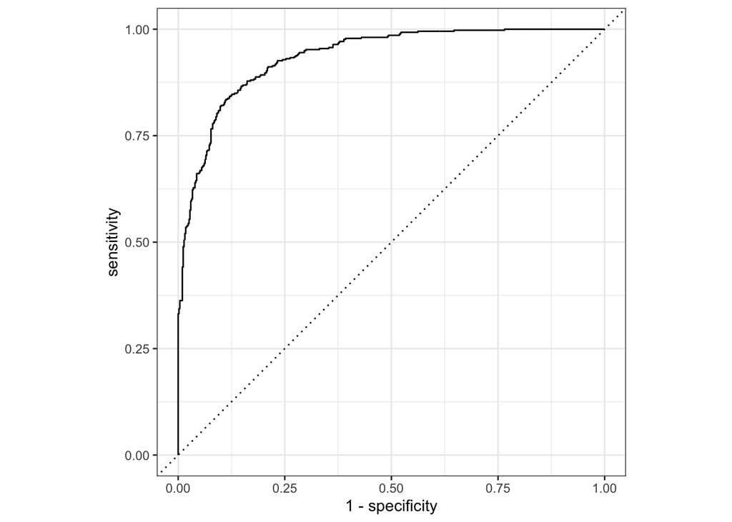

```r
last_fit_results %>%
  roc_curve(truth = customer_status, estimate = .pred_closed_account) %>%
  autoplot()
```

# Model 2 (LDA)

```r
lda_model <- discrim_regularized(frac_common_cov = 1) %>%
             set_engine('klaR') %>%
             set_mode('classification')

lda_wf <- workflow() %>%
          add_model(lda_model) %>%
          add_recipe(customer_recipe)

last_fit_lda <- lda_wf %>%
                last_fit(split = customer_split)
lda_predictions <- last_fit_lda %>%
                     collect_predictions()
last_fit_lda %>% collect_metrics()
```

| .metric | .estimator | .estimate | .config |
| --- | --- | --- | --- |
| accuracy | binary | 0.8606911 | Preprocessor1_Model1 |
| roc_auc | binary | 0.9355420 | Preprocessor1_Model1 |

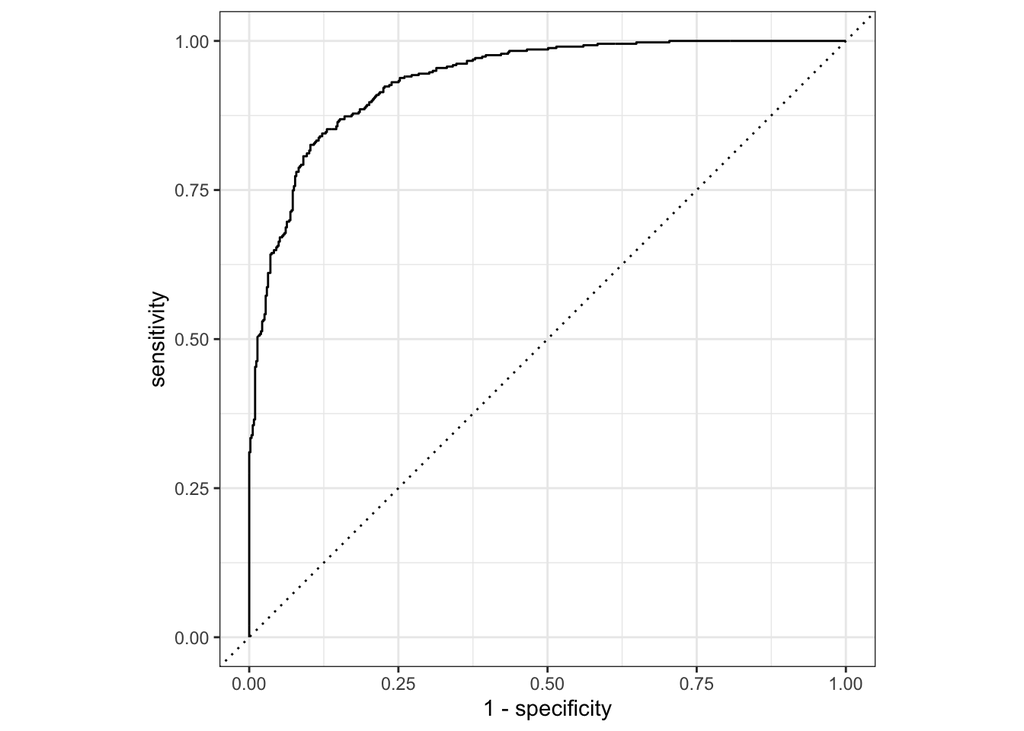

```r
lda_predictions %>%
  roc_curve(truth = customer_status, .pred_closed_account) %>%
  autoplot()
```

# Model 3 (QDA)

```r
qda_model <- discrim_regularized(frac_common_cov = 0) %>%
             set_engine('klaR') %>%
             set_mode('classification')
qda_wf <- workflow() %>%
          add_model(qda_model) %>%
          add_recipe(customer_recipe)
last_fit_qda <- qda_wf %>%
                last_fit(split = customer_split)
last_fit_qda %>% collect_metrics()
```

| .metric | .estimator | .estimate | .config |
| --- | --- | --- | --- |
| accuracy | binary | 0.8822894 | Preprocessor1_Model1 |
| roc_auc | binary | 0.9468303 | Preprocessor1_Model1 |

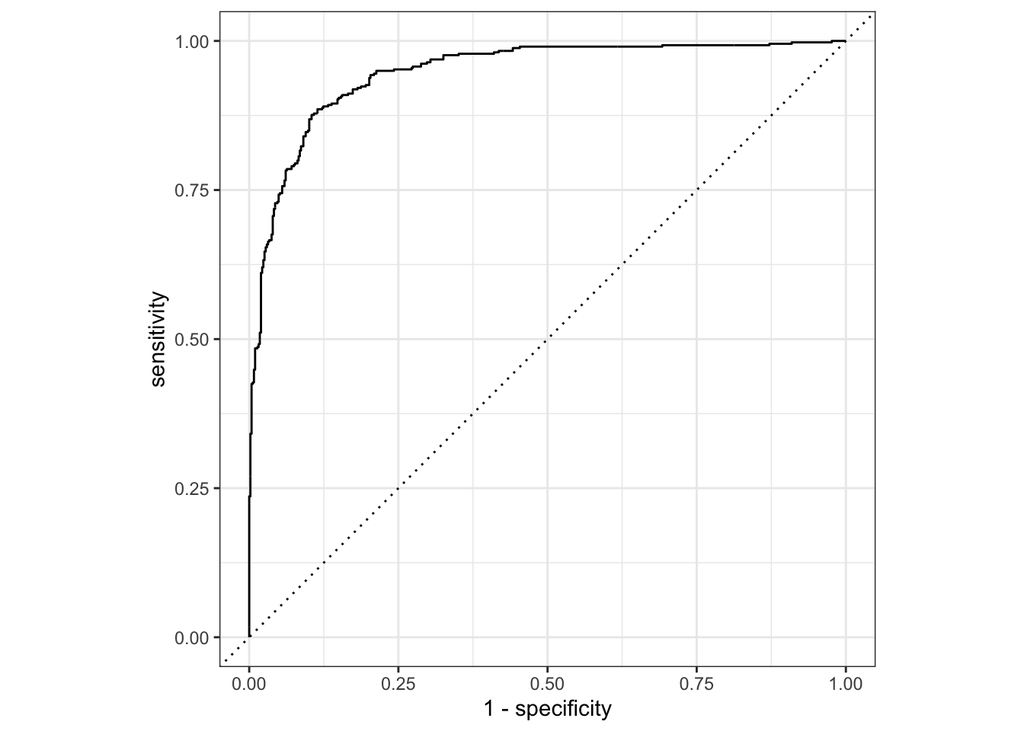

```r
qda_predictions <- last_fit_qda %>%
                     collect_predictions()

qda_predictions %>%
  roc_curve(truth = customer_status, .pred_closed_account) %>%
  autoplot()
```